# Project3_Term_Deposit_Sale_Hakeem_Ogunleye-Final

### Term Deposit Subscription Prediction

**Import libraries and the dataset, check datatype, statistical summary,shape,null values or incorrect imputation**

```python
import warnings
warnings.filterwarnings('ignore')
```

```python
## importing libaries

import pandas as pd
import numpy as np

import matplotlib.pyplot as plt
%matplotlib inline
import seaborn as sns

from sklearn.model_selection import train_test_split
from sklearn.linear_model import LogisticRegression   # importing logistic regression from scikit learn
from sklearn.tree import DecisionTreeClassifier
from sklearn.metrics import accuracy_score, f1_score, recall_score, precision_score, confusion_matrix, roc_auc_score


from yellowbrick.classifier import ClassificationReport, ROCAUC

plt.style.use('ggplot')
pd.options.display.float_format = '{:,.4f}'.format
from IPython.core.display import display, HTML
display(HTML("<style>.container { width:85% !important; }</style>"))
```

```python
df = pd.read_csv('bank-full.csv')
```

*Quick overview of data, i.e. checck types, shape, inferential statistics and null values*

```python
df.head(10)
```

|  | age | job | marital | education | default | balance | housing | loan | contact | day | month | duration | campaign | pdays | previous | poutcome | Target |
| --- | --- | --- | --- | --- | --- | --- | --- | --- | --- | --- | --- | --- | --- | --- | --- | --- | --- |
| 0 | 58 | management | married | tertiary | no | 2143 | yes | no | unknown | 5 | may | 261 | 1 | -1 | 0 | unknown | no |
| 1 | 44 | technician | single | secondary | no | 29 | yes | no | unknown | 5 | may | 151 | 1 | -1 | 0 | unknown | no |
| 2 | 33 | entrepreneur | married | secondary | no | 2 | yes | yes | unknown | 5 | may | 76 | 1 | -1 | 0 | unknown | no |
| 3 | 47 | blue-collar | married | unknown | no | 1506 | yes | no | unknown | 5 | may | 92 | 1 | -1 | 0 | unknown | no |
| 4 | 33 | unknown | single | unknown | no | 1 | no | no | unknown | 5 | may | 198 | 1 | -1 | 0 | unknown | no |
| 5 | 35 | management | married | tertiary | no | 231 | yes | no | unknown | 5 | may | 139 | 1 | -1 | 0 | unknown | no |
| 6 | 28 | management | single | tertiary | no | 447 | yes | yes | unknown | 5 | may | 217 | 1 | -1 | 0 | unknown | no |
| 7 | 42 | entrepreneur | divorced | tertiary | yes | 2 | yes | no | unknown | 5 | may | 380 | 1 | -1 | 0 | unknown | no |
| 8 | 58 | retired | married | primary | no | 121 | yes | no | unknown | 5 | may | 50 | 1 | -1 | 0 | unknown | no |
| 9 | 43 | technician | single | secondary | no | 593 | yes | no | unknown | 5 | may | 55 | 1 | -1 | 0 | unknown | no |

```python
df.shape
```

```
(45211, 17)
```

```python
df.dtypes
```

```
age           int64
job          object
marital      object
education    object
default      object
balance       int64
housing      object
loan         object
contact      object
day           int64
month        object
duration      int64
campaign      int64
pdays         int64
previous      int64
poutcome     object
Target       object
dtype: object
```

```python
#we have lots of columns that are seen as objects. Convert them to categorical columns

for feature in df.columns: # Loop through all columns in the dataframe
    if df[feature].dtype == 'object': # Only apply for columns with object type
        df[feature] = pd.Categorical(df[feature]) # convert to categorical type
df.dtypes
```

```
age             int64
job          category
marital      category
education    category
default      category
balance         int64
housing      category
loan         category
contact      category
day             int64
month        category
duration        int64
campaign        int64
pdays           int64
previous        int64
poutcome     category
Target       category
dtype: object
```

```python
df.describe().transpose()
```

|  | count | mean | std | min | 25% | 50% | 75% | max |
| --- | --- | --- | --- | --- | --- | --- | --- | --- |
| age | 45,211.0000 | 40.9362 | 10.6188 | 18.0000 | 33.0000 | 39.0000 | 48.0000 | 95.0000 |
| balance | 45,211.0000 | 1,362.2721 | 3,044.7658 | -8,019.0000 | 72.0000 | 448.0000 | 1,428.0000 | 102,127.0000 |
| day | 45,211.0000 | 15.8064 | 8.3225 | 1.0000 | 8.0000 | 16.0000 | 21.0000 | 31.0000 |
| duration | 45,211.0000 | 258.1631 | 257.5278 | 0.0000 | 103.0000 | 180.0000 | 319.0000 | 4,918.0000 |
| campaign | 45,211.0000 | 2.7638 | 3.0980 | 1.0000 | 1.0000 | 2.0000 | 3.0000 | 63.0000 |
| pdays | 45,211.0000 | 40.1978 | 100.1287 | -1.0000 | -1.0000 | -1.0000 | -1.0000 | 871.0000 |
| previous | 45,211.0000 | 0.5803 | 2.3034 | 0.0000 | 0.0000 | 0.0000 | 0.0000 | 275.0000 |

*Observation*  
Balance, duration, pdays abd previous are highly right skewed. The max values are also high showing a potential for outliers

```python
df.isnull().sum()
```

```
age          0
job          0
marital      0
education    0
default      0
balance      0
housing      0
loan         0
contact      0
day          0
month        0
duration     0
campaign     0
pdays        0
previous     0
poutcome     0
Target       0
dtype: int64
```

*No null values in our data*

### Univariate Analysis

*Value counts for categorical data types*

```python
print('Value Counts percentage for Categorical Data')
print()
for i in list(df.columns[df.dtypes =='category']):
    print(df[i].value_counts(normalize=True)*100)
    print()
```

```
Value Counts percentage for Categorical Data

blue-collar     21.5257
management      20.9197
technician      16.8034
admin.          11.4375
services         9.1880
retired          5.0076
self-employed    3.4925
entrepreneur     3.2890
unemployed       2.8820
housemaid        2.7427
student          2.0747
unknown          0.6370
Name: job, dtype: float64

married    60.1933
single     28.2896
divorced   11.5171
Name: marital, dtype: float64

secondary   51.3194
tertiary    29.4198
primary     15.1534
unknown      4.1074
Name: education, dtype: float64

no    98.1973
yes    1.8027
Name: default, dtype: float64

yes   55.5838
no    44.4162
Name: housing, dtype: float64

no    83.9774
yes   16.0226
Name: loan, dtype: float64

cellular    64.7741
```

[output cut: 12 more lines]

```
oct    1.6323
sep    1.2807
mar    1.0551
dec    0.4733
Name: month, dtype: float64

unknown   81.7478
failure   10.8403
other      4.0698
success    3.3421
Name: poutcome, dtype: float64

no    88.3015
yes   11.6985
Name: Target, dtype: float64
```

**Observations from categorical univariate counts**

1. There is so much unknown in the **poutcome** column and it highly skews the distribution. Futher investigation would be needed to understand why the outcome was not recorded. Could it be a mojority were not profiled in the last campaign and are new customers? This column cannot be easily dropped as it explains the outcome of the previous campaign
2. There is very limited variability in customers who have credit in **default**. 98% have no defaults. This column would be dropped as it explains no variability in data.
3. The **Target** column is also highly skewed. Over 88% didn't subbscribe to the term deposit. Futher multi-variate analysis required.
4. A high percentage (84%) of customers have NO personal **loans**. A high skew too.
5. A majority of the last **contact** were in the middle third of the year (i.e. may, jun, july, aug) and also in November.

```python
#convert month to int represenation
months = {'jan':1, 'feb':2, 'mar':3, 'apr':4, 'may':5, 'jun':6, 'jul':7, 'aug':8, 'sep':9, 'oct':10, 'nov':11, 'dec':12 }
df.month = df.month.map(months)
df.month = df.month.astype(int)
```

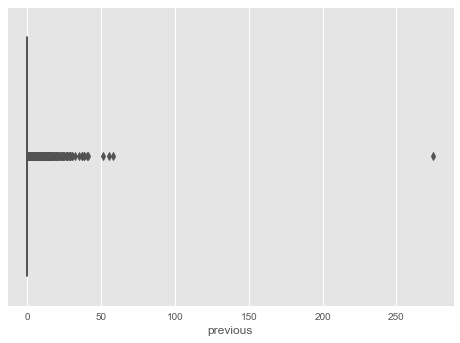

```python
#previous shows a very high max value. Perhaps an outlier
sns.boxplot(x='previous', data=df)
```

```python
df[df['previous'] > 100]
```

|  | age | job | marital | education | default | balance | housing | loan | contact | day | month | duration | campaign | pdays | previous | poutcome | Target |
| --- | --- | --- | --- | --- | --- | --- | --- | --- | --- | --- | --- | --- | --- | --- | --- | --- | --- |
| 29182 | 40 | management | married | tertiary | no | 543 | yes | no | cellular | 2 | 2 | 349 | 2 | 262 | 275 | other | no |

```python
#this is a single record perhaps an error entry, so drop it
df = df[df['previous'] < 100]
```

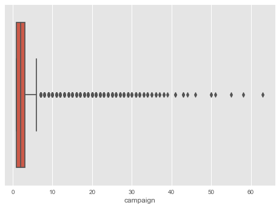

```python
#campaign shows a very high max value. Perhaps presence of outliers
sns.boxplot(x='campaign', data=df)
```

```python
df[df['campaign'] > 20]['campaign'].shape
```

```
(244,)
```

```python
df[df['campaign'] > 20]['Target'].value_counts(normalize=True)
```

```
no    0.9836
yes   0.0164
Name: Target, dtype: float64
```

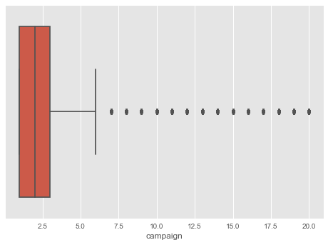

```python
#only 244 of 45210 records were called more than 20 times. only 1.6% of those responded yes.
#therefore dropping rows with campaign > 20 as they are outliers
df = df[df['campaign'] < 21]

#review box plot for campaign
sns.boxplot(x='campaign', data=df)
```

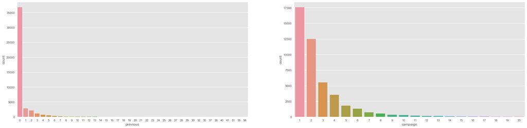

```python
fig, axs = plt.subplots(ncols = 2, nrows=1, figsize = (30, 7))
sns.countplot(df['previous'], ax=axs[0])
sns.countplot(df['campaign'], ax=axs[1])
```

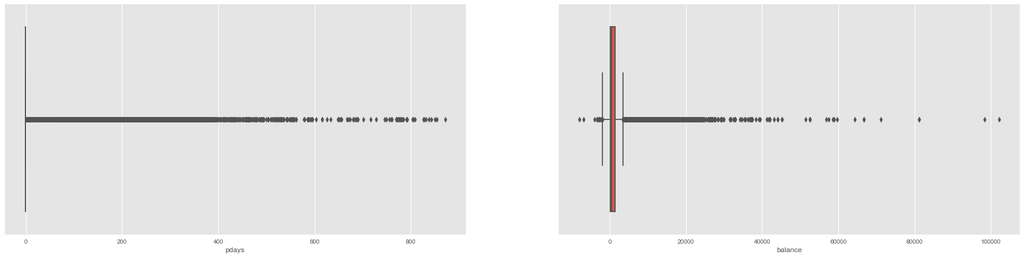

```python
#previous shows a very high max value. Perhaps an outlier
fig, axs = plt.subplots(ncols = 2, nrows=1, figsize = (30, 7))
sns.boxplot(x='pdays', data=df, ax=axs[0])
sns.boxplot(x='balance', data=df, ax=axs[1])
```

```python
df[df['balance'] > 40000]['balance'].shape
df[df['balance'] > 40000]['Target'].value_counts(normalize=True)

#some variability in Target about value with outliers so no treatment for now. Decision Tree and Emsemble Techniques based classifiers are generally not biased by ouliers
```

```
no    0.8148
yes   0.1852
Name: Target, dtype: float64
```

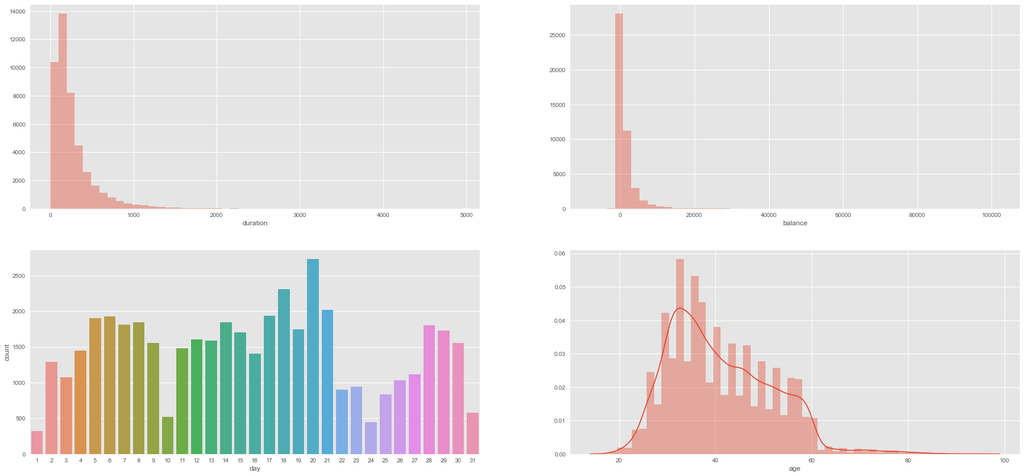

```python
fig, axs = plt.subplots(ncols = 2, nrows=2, figsize = (30, 14))
sns.distplot(df['duration'], kde=False, ax=axs[0,0])
sns.distplot(df['balance'], kde=False, ax=axs[0,1])
sns.countplot(df['day'], ax=axs[1,0])
sns.distplot(df['age'], ax=axs[1,1])
```

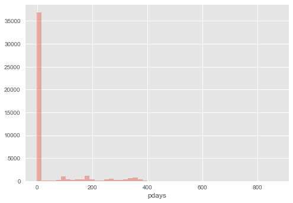

```python
sns.distplot(df['pdays'], kde=False)
```

```
no    88.2467
yes   11.7533
Name: Target, dtype: float64
```

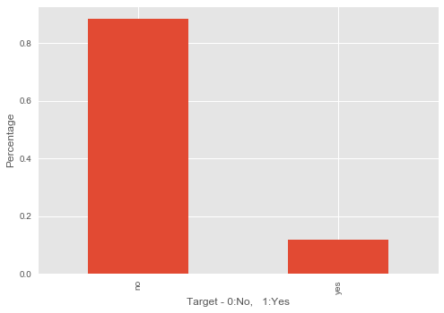

```python
print(df['Target'].value_counts(normalize=True)*100)
print()
df['Target'].value_counts(normalize=True).plot(kind='bar')
plt.xlabel("Target - 0:No,   1:Yes")
plt.ylabel("Percentage")
plt.show()
```

*Our target variable is highly skewed. This would affect the accuracy of the model as no doing anything would already suggest an 88% accuracy if we predicted "No" all the time.*

### Multi-variate analysis

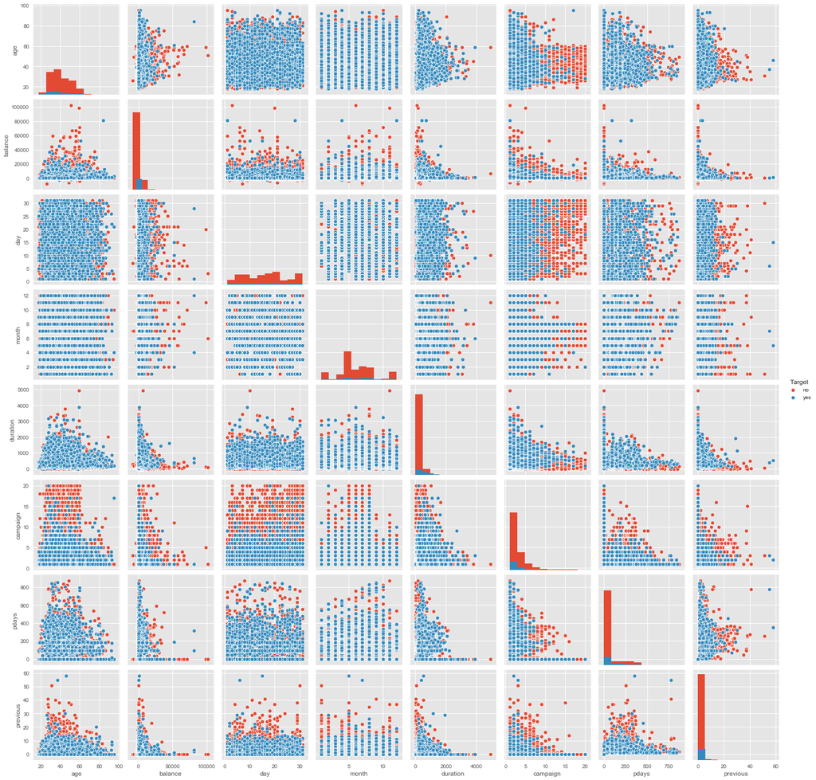

```python
sns.pairplot(df, hue='Target', diag_kind='hist')
plt.show()
```

*Observation*  
Not much trends derived amongst the variables but it would seem as the more contacts made in a campaign vs (age < 60 and regarless of day), the less likely the customer is to subscribe to a term deposit.

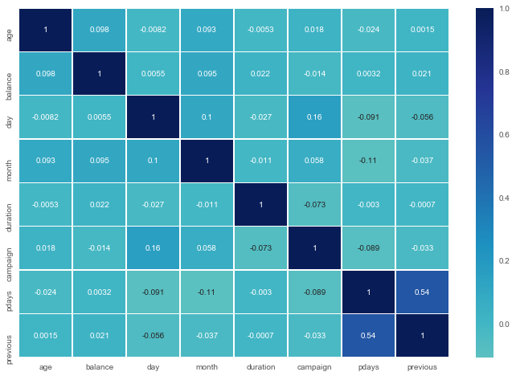

```python
plt.figure(figsize=(12,8))

sns.heatmap(df.corr(),
            annot=True,
            linewidths=.5,
            center=0,
            cbar=True,
            cmap="YlGnBu")

plt.show()
```

*Observation for Correlation*  
Generally no strong correlation among the independent variables except for pdays and previous has Pearson's correlation of 0.54

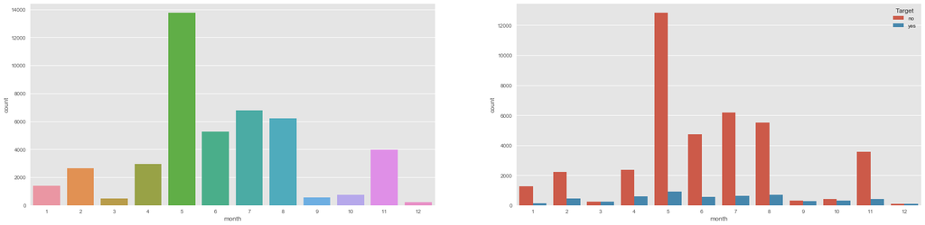

```python
fig, axs = plt.subplots(ncols = 2, nrows=1, figsize = (30, 7))
sns.countplot(df['month'], ax=axs[0])
sns.countplot(df['month'], hue=df['Target'], ax=axs[1])
```

```python
print("Month of last call and percentage of yes and no responses ");
pd.crosstab(df['month'], df['Target'],normalize='index')
```

```
Month of last call and percentage of yes and no responses
```

| Target month | no | yes |
| --- | --- | --- |
| 1 | 0.8988 | 0.1012 |
| 2 | 0.8337 | 0.1663 |
| 3 | 0.4801 | 0.5199 |
| 4 | 0.8031 | 0.1969 |
| 5 | 0.9327 | 0.0673 |
| 6 | 0.8966 | 0.1034 |
| 7 | 0.9080 | 0.0920 |
| 8 | 0.8890 | 0.1110 |
| 9 | 0.5354 | 0.4646 |
| 10 | 0.5623 | 0.4377 |
| 11 | 0.8985 | 0.1015 |
| 12 | 0.5327 | 0.4673 |

*Observations for Months*  
Most customers were last contacted in the summer months of **May,June,July and August and in the Autumn in November.However, the percentage of responses to number of calls we very low**.  
Moreover for customers with last contact in the months of **March, Sept, October, December the subscription rate was quite high. Perhaps there should be emphasis on targeting calls during this months**

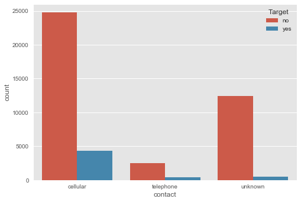

```python
sns.countplot(df['contact'], hue=df['Target'])
```

```python
print("Contact Type and percentage of yes and no responses ");
pd.crosstab(df['contact'], df['Target'],normalize='all')
```

```
Contact Type and percentage of yes and no responses
```

| Target contact | no | yes |
| --- | --- | --- |
| cellular | 0.5511 | 0.0971 |
| telephone | 0.0555 | 0.0087 |
| unknown | 0.2758 | 0.0118 |

*Contacting via cellular has a relatively higher chance of getting a customer to subscribe*

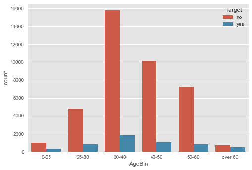

```python
bin_edges = [0, 25, 30, 40, 50, 60, 90]         # edges to define intervals
bin_labels = ['0-25','25-30','30-40','40-50','50-60','over 60',]
df['AgeBin'] = pd.cut(df['age'], bins=bin_edges, labels=bin_labels)
sns.countplot(x = 'AgeBin',data=df,hue='Target')
```

```python
print("Contact Type and percentage of yes and no responses ");
pd.crosstab(df['AgeBin'], df['Target'],normalize='all')
```

```
Contact Type and percentage of yes and no responses
```

| Target AgeBin | no | yes |
| --- | --- | --- |
| 0-25 | 0.0224 | 0.0071 |
| 25-30 | 0.1075 | 0.0183 |
| 30-40 | 0.3509 | 0.0403 |
| 40-50 | 0.2259 | 0.0226 |
| 50-60 | 0.1607 | 0.0180 |
| over 60 | 0.0152 | 0.0111 |

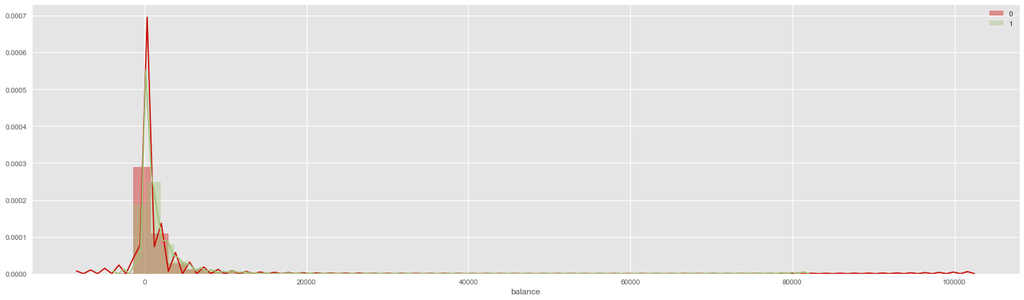

```python
fig, axs = plt.subplots(ncols = 1, figsize = (25, 7))
sns.distplot(df[df['Target']=="no"]['balance'],color='r',label=0)
sns.distplot(df[df['Target']=="yes"]['balance'],color='g',label=1)
plt.legend()
plt.show()
```

*Not much differentiation on subscribing based on whether a customer had a balance*

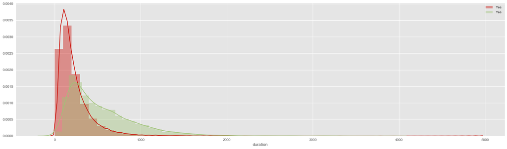

```python
fig, axs = plt.subplots(ncols = 1, figsize = (25, 7))
sns.distplot(df[df['Target']=="no"]['duration'],color='r',label="Yes")
sns.distplot(df[df['Target']=="yes"]['duration'],color='g',label="Yes")
plt.legend()
plt.show()
```

*The longer the duration the better the chance a customer would be willing to subscribe*

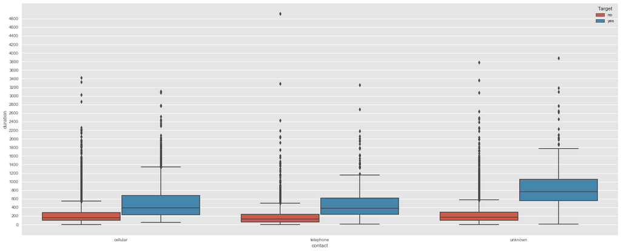

```python
fig, axs = plt.subplots(ncols = 1, figsize = (25, 10))
sns.boxplot(x='contact', y='duration', hue='Target', data=df)
axs.set_yticks(np.arange(0, 5000, 200))
plt.show()
```

```python
df[df['duration'] > 200].groupby('contact')['Target'].value_counts(normalize=True)
```

```
contact    Target
cellular   no       0.7339
           yes      0.2661
telephone  no       0.7085
           yes      0.2915
unknown    no       0.9142
           yes      0.0858
Name: Target, dtype: float64
```

```python
df[df['duration'] < 200].groupby('contact')['Target'].value_counts(normalize=True)
```

```
contact    Target
cellular   no       0.9501
           yes      0.0499
telephone  no       0.9657
           yes      0.0343
unknown    no       0.9950
           yes      0.0050
Name: Target, dtype: float64
```

Regardless of means of communication, the longer the duration then the more likely a customer would subscribe to a term deposit  
For contact via cellullar or telephone, spending a duration of at least 200 seconds results in a higher chance for term deposit subscription

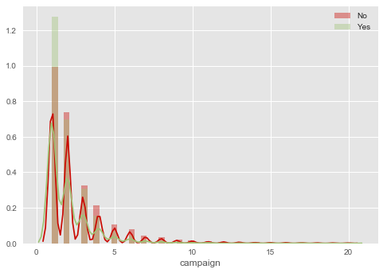

```python
sns.distplot(df[df['Target']=="no"]['campaign'],color='r',label="No")
sns.distplot(df[df['Target']=="yes"]['campaign'],color='g',label="Yes")
plt.legend()
plt.show()
```

```python
pd.crosstab(df['poutcome'], df['Target'],normalize='all')
```

| Target poutcome | no | yes |
| --- | --- | --- |
| failure | 0.0952 | 0.0137 |
| other | 0.0341 | 0.0068 |
| success | 0.0119 | 0.0217 |
| unknown | 0.7413 | 0.0752 |

```python
pd.crosstab(df['default'], df['Target'],normalize='all')
```

| Target default | no | yes |
| --- | --- | --- |
| no | 0.8657 | 0.1164 |
| yes | 0.0168 | 0.0012 |

```python
pd.crosstab(df['loan'], df['Target'],normalize='all')
```

| Target loan | no | yes |
| --- | --- | --- |
| no | 0.7333 | 0.1068 |
| yes | 0.1492 | 0.0107 |

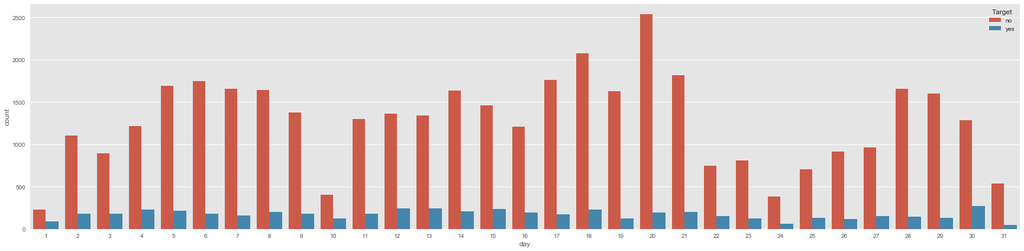

```python
fig, axs = plt.subplots(ncols = 1, nrows=1, figsize = (30, 7))
sns.countplot(df['day'], hue=df['Target'])
```

### Summary Conclusion

1. Regardless of means of communication, the longer the duration then the more likely a customer would subscribe to a term deposit. (when contacting customer via cellullar or telephone, spending a duration of at least 200 seconds results in a higher chance for term deposit subscription)
2. default is highly skewed with over 98% of customers having no default. column would be dropped from modeling
3. Contacting via cellular has a slighly higher chance of getting a customer to subscribe
4. Most customers were last contacted in the summer months of May,June,July and August and in the Autumn in November.However, the percentage of responses to number of calls we very low.  
   Moreover for customers with last contact in the months of March, Sept, October, December the subscription rate was quite high. Perhaps there should be emphasis on targeting calls during this months
5. Generally no strong correlation among the independent variables except for pdays and previous has Pearson's correlation of 0.54
6. Our target variable is highly skewed. This would affect the accuracy of the model as no doing anything would already suggest an 88% accuracy if we predicted "No" all the time.
7. independents variables would be binned but not necessarily scaled since decision trees and ensemble techniques are less suceptible to outliers

### 2. Prepare model for data analytics

```python
#data cleaup
data = df.copy();
data = data.drop(["default", "AgeBin"], axis=1)

#combine similar job types as follows: (blue_collar and technician), (admin, management), (services,housemaid), (retired)
replaceStruct = {
                "job":     {"technician": "blue-collar", "entrepreneur": "self-employed" ,"admin.": "admin", "management":"admin" ,"housemaid":"services"},
                "Target":     {"no": 0, "yes": 1 },
                "housing":     {"no": 0, "yes": 1 },
                "loan":     {"no": 0, "yes": 1 }
            }

oneHotCols=["job", "marital","education","contact","poutcome"]
```

```python
data=data.replace(replaceStruct)
data=pd.get_dummies(data, columns=oneHotCols, drop_first=True)

data.head(10)
```

|  | age | balance | housing | loan | day | month | duration | campaign | pdays | previous | ... | marital_married | marital_single | education_secondary | education_tertiary | education_unknown | contact_telephone | contact_unknown | poutcome_other | poutcome_success | poutcome_unknown |
| --- | --- | --- | --- | --- | --- | --- | --- | --- | --- | --- | --- | --- | --- | --- | --- | --- | --- | --- | --- | --- | --- |
| 0 | 58 | 2143 | 1 | 0 | 5 | 5 | 261 | 1 | -1 | 0 | ... | 1 | 0 | 0 | 1 | 0 | 0 | 1 | 0 | 0 | 1 |
| 1 | 44 | 29 | 1 | 0 | 5 | 5 | 151 | 1 | -1 | 0 | ... | 0 | 1 | 1 | 0 | 0 | 0 | 1 | 0 | 0 | 1 |
| 2 | 33 | 2 | 1 | 1 | 5 | 5 | 76 | 1 | -1 | 0 | ... | 1 | 0 | 1 | 0 | 0 | 0 | 1 | 0 | 0 | 1 |
| 3 | 47 | 1506 | 1 | 0 | 5 | 5 | 92 | 1 | -1 | 0 | ... | 1 | 0 | 0 | 0 | 1 | 0 | 1 | 0 | 0 | 1 |
| 4 | 33 | 1 | 0 | 0 | 5 | 5 | 198 | 1 | -1 | 0 | ... | 0 | 1 | 0 | 0 | 1 | 0 | 1 | 0 | 0 | 1 |
| 5 | 35 | 231 | 1 | 0 | 5 | 5 | 139 | 1 | -1 | 0 | ... | 1 | 0 | 0 | 1 | 0 | 0 | 1 | 0 | 0 | 1 |
| 6 | 28 | 447 | 1 | 1 | 5 | 5 | 217 | 1 | -1 | 0 | ... | 0 | 1 | 0 | 1 | 0 | 0 | 1 | 0 | 0 | 1 |
| 7 | 42 | 2 | 1 | 0 | 5 | 5 | 380 | 1 | -1 | 0 | ... | 0 | 0 | 0 | 1 | 0 | 0 | 1 | 0 | 0 | 1 |
| 8 | 58 | 121 | 1 | 0 | 5 | 5 | 50 | 1 | -1 | 0 | ... | 1 | 0 | 0 | 0 | 0 | 0 | 1 | 0 | 0 | 1 |
| 9 | 43 | 593 | 1 | 0 | 5 | 5 | 55 | 1 | -1 | 0 | ... | 0 | 1 | 1 | 0 | 0 | 0 | 1 | 0 | 0 | 1 |

10 rows × 28 columns

#### 2.d Create training and test set at 70:30 ratio

```python
r_seed = 27
X = data.loc[:, data.columns != 'Target']  # independent variables
Y = data.loc[:, data.columns == 'Target']  # Target variable

X_train, X_test, y_train, y_test = train_test_split(X, Y, test_size=0.30,random_state=r_seed)
print('Check spilt ratio on training data for y variable')
print(y_train['Target'].value_counts(normalize=True))
print()
print('Check spilt ratio on testing data for y variable')
print(y_test['Target'].value_counts(normalize=True))
```

```
Check spilt ratio on training data for y variable
0   0.8816
1   0.1184
Name: Target, dtype: float64

Check spilt ratio on testing data for y variable
0   0.8844
1   0.1156
Name: Target, dtype: float64
```